# STAT 475 Sales Report

Adam Bennett

2023-04-28

In this report, I will be explaining my process of forecasting The ABC Company’s future sales for Product A and Product C. I will be using the given historical sales data to make an informed prediction for the next 12 months of sales. I will provide graphics and reasoning for each step of the process.

# Product A

Here is a view of our historical sales data of Product A.

```
##      Jan Feb Mar Apr May Jun Jul Aug Sep Oct Nov Dec
## 2003              10  16  22  25  29  35  42  44  48
## 2004  49  54  58  58  62  65  68  74  79  82  85  91
## 2005  90  90  95  97  92  89  87  85  83  84  85  86
## 2006  89  93  98 102 106 111 111 115 119 122 123 124
## 2007 122 122 127 129 129 130 134 139 141 145 149 152
## 2008 157 161 163 167 175 176 180 185 189 193 197 201
## 2009 208 212 213 213 216 222 225 228 229 233 239 245
## 2010 245 250 256 260 265 273 275 277 278 279 281 281
## 2011 285 288 293 293 297 305 312 317 323 329 336 338
## 2012 340 343 346 344 344 348 349 352 356 359 362 360
## 2013 363 365 365 365 367 369 371 372 376 382 388 395
## 2014 402 408 415 421 425 428 433 436 440 445 448 450
## 2015 453 459 462 466 470 472 476 481 484 487 493 496
## 2016 502 504 509 516 518 519 520 525 530 533 535 538
## 2017 544 549 553 560 562 566 568 568 568 570 572 575
## 2018 580 583 589 596 602 604 609 614 616 619 624 625
## 2019 629 629 629 633 634 632 635 638 641 646 649 652
## 2020 651 654 658 662 666 670 674 676 678 680 683 683
## 2021 685 687 687 686 686 687 687 689 689 687 689 691
## 2022 692 696 696 696 699 697 697 701 701 700 701 702
## 2023 704 707 711
```

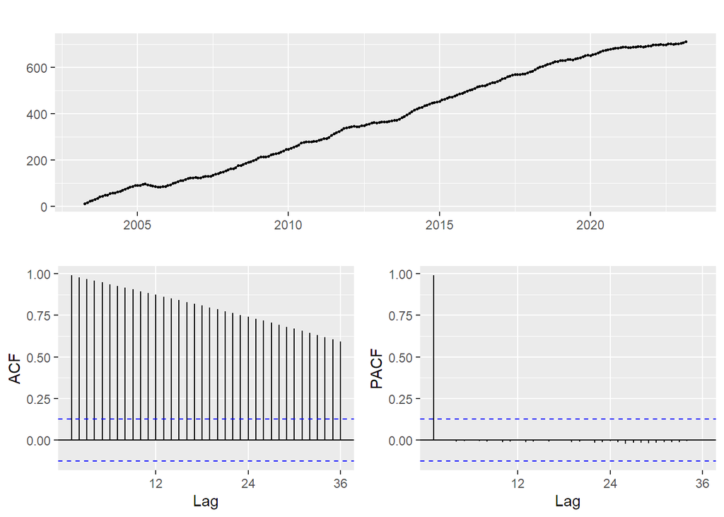

First differencing of the data gives us a stationary series, facilitating accurate modelling.

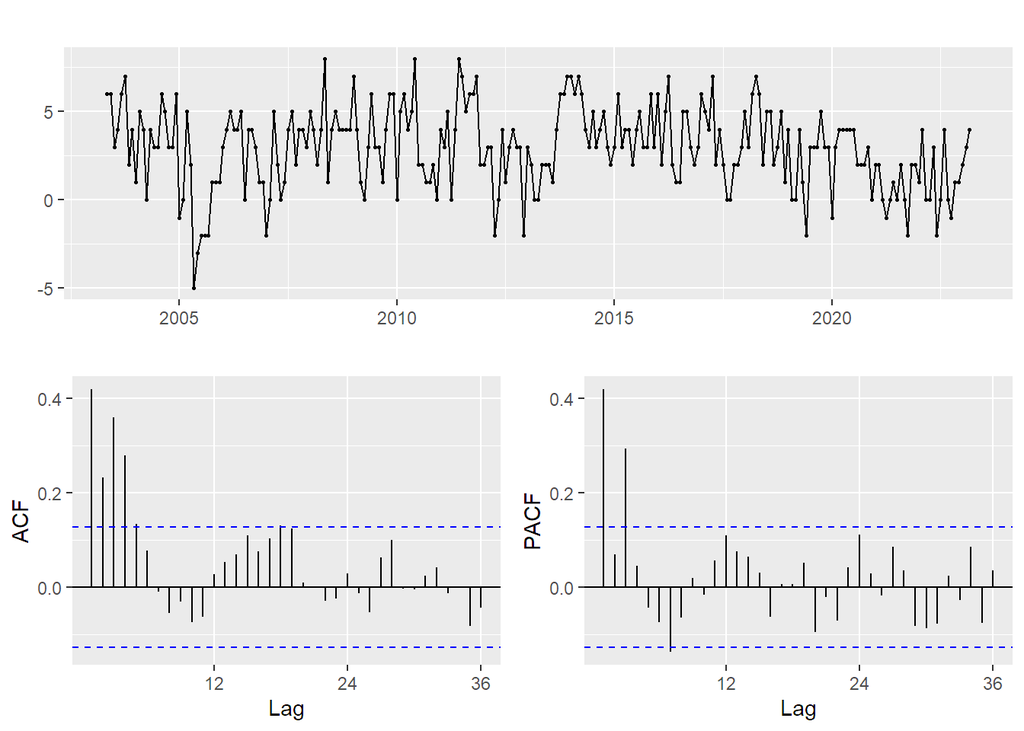

Analysis of the ACF and PACF of the differenced data lead me to three potential models for forecasting.

- ARIMA(3,1,0) with drift:

```
## Series: data.A
## ARIMA(3,1,0) with drift
##
## Coefficients:
##          ar1      ar2     ar3  drift
##       0.3685  -0.0421  0.2915  2.966
## s.e.  0.0618   0.0663  0.0618  0.338
##
## sigma^2 = 4.154:  log likelihood = -507.52
## AIC=1025.05   AICc=1025.3   BIC=1042.43
```

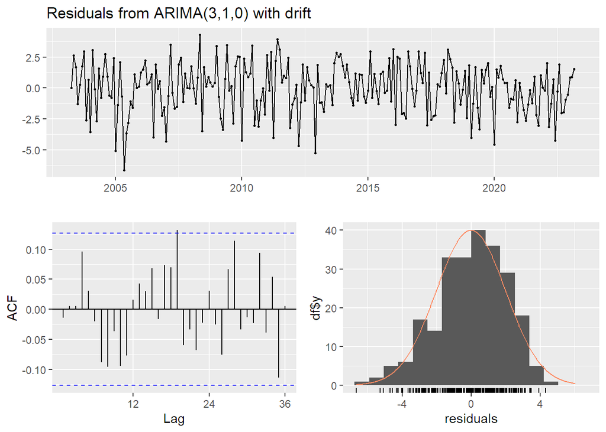

```
##
##  Ljung-Box test
##
## data:  Residuals from ARIMA(3,1,0) with drift
## Q* = 23.122, df = 21, p-value = 0.3375
##
## Model df: 3.   Total lags used: 24
```

- ARIMA(1,1,3) with drift:

```
## Series: data.A
## ARIMA(1,1,3) with drift
##
## Coefficients:
##          ar1      ma1      ma2     ma3   drift
##       0.7124  -0.4043  -0.1270  0.2966  2.9680
## s.e.  0.0786   0.0905   0.0625  0.0661  0.3414
##
## sigma^2 = 4.108:  log likelihood = -505.74
## AIC=1023.48   AICc=1023.84   BIC=1044.34
```

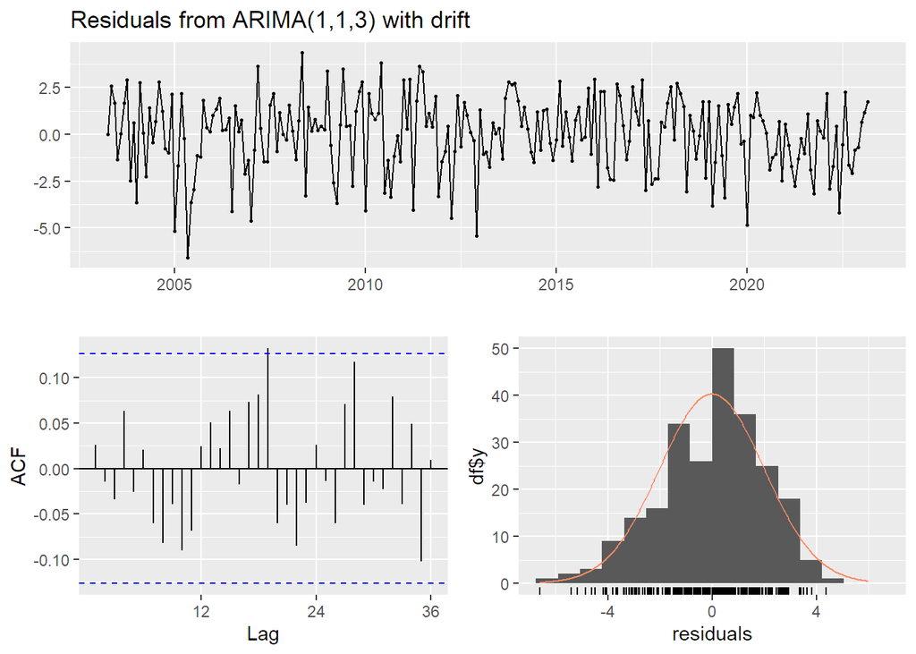

```
##
##  Ljung-Box test
##
## data:  Residuals from ARIMA(1,1,3) with drift
## Q* = 21.67, df = 20, p-value = 0.3587
##
## Model df: 4.   Total lags used: 24
```

- ARIMA(2,1,3) with drift:

```
## Series: data.A
## ARIMA(2,1,3) with drift
##
## Coefficients:
##          ar1      ar2      ma1     ma2     ma3   drift
##       1.1118  -0.3743  -0.7798  0.0924  0.3322  2.9603
## s.e.  0.2191   0.1729   0.2076  0.1306  0.0647  0.3134
##
## sigma^2 = 4.057:  log likelihood = -503.78
## AIC=1021.56   AICc=1022.05   BIC=1045.9
```

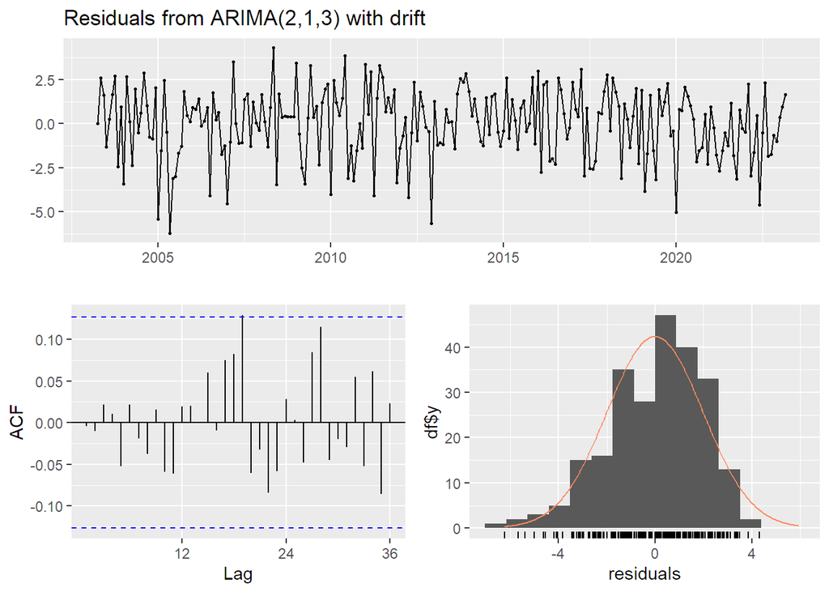

```
##
##  Ljung-Box test
##
## data:  Residuals from ARIMA(2,1,3) with drift
## Q* = 16.279, df = 19, p-value = 0.6386
##
## Model df: 5.   Total lags used: 24
```

All three of our models perform roughly evenly overall after considering AIC values, residual autocorrelation tests, and parameter significance. Thus, I will be forecasting using the simplest model, which is ARIMA(3,1,0) with drift.

Thus, this is our prediction for the next 12 months of sales for Product A:

```
##          Point Forecast    Lo 70    Hi 70    Lo 90    Hi 90
## Apr 2023       714.0640 711.9516 716.1764 710.7115 717.4165
## May 2023       717.0325 713.4522 720.6128 711.3504 722.7146
## Jun 2023       720.2967 715.5682 725.0252 712.7924 727.8009
## Jul 2023       723.4010 717.3694 729.4326 713.8286 732.9734
## Aug 2023       726.4061 719.0535 733.7587 714.7373 738.0749
## Sep 2023       729.4676 720.8968 738.0385 715.8654 743.0699
## Oct 2023       732.5075 722.7565 742.2584 717.0324 747.9825
## Nov 2023       735.5081 724.6104 746.4057 718.2132 752.8030
## Dec 2023       738.5115 726.5243 750.4988 719.4874 757.5357
## Jan 2024       741.5114 728.4832 754.5396 720.8353 762.1875
## Feb 2024       744.4984 730.4705 758.5263 722.2356 766.7611
## Mar 2024       747.4816 732.4966 762.4666 723.6999 771.2633
```

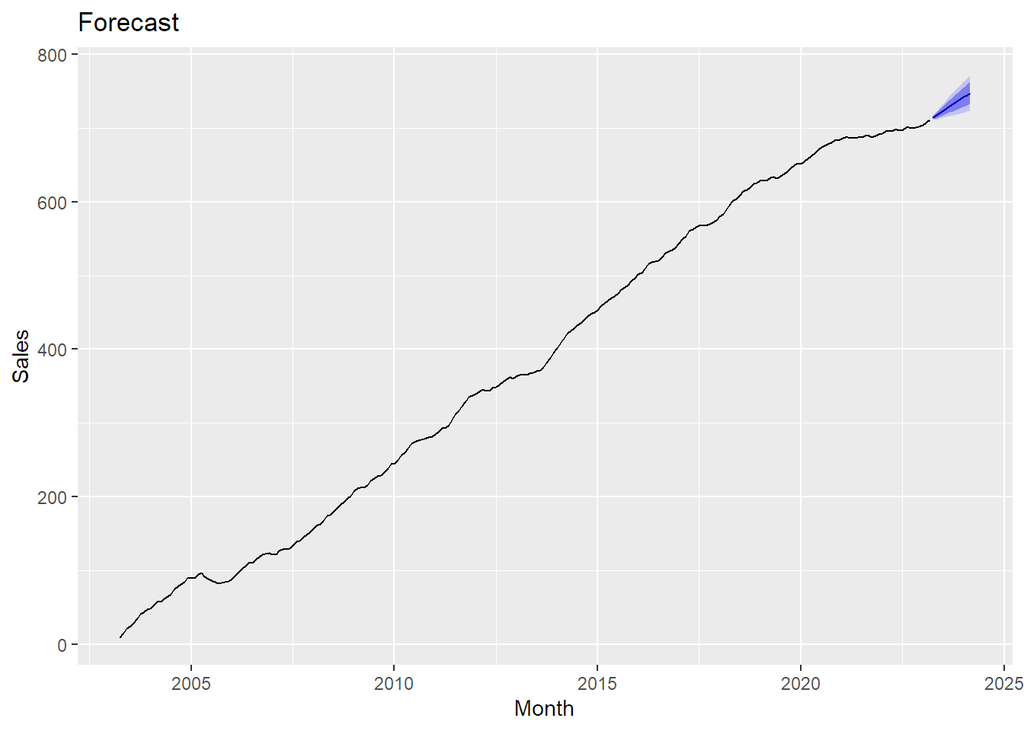

# Product C

Here is a view of our historical sales data of Product C.

```
##      Jan Feb Mar Apr May Jun Jul Aug Sep Oct Nov Dec
## 2013             434 446 474 468 452 479 503 503 481
## 2014 448 416 446 440 462 490 479 460 505 540 540 520
## 2015 475 438 488 497 506 552 528 543 552 584 584 562
## 2016 527 499 533 541 555 575 557 560 611 627 642 598
## 2017 572 543 577 580 580 634 633 625 643 669 679 636
## 2018 601 555 587 591 568 633 623 632 669 713 703 663
## 2019 625 590 625 642 631 673 675 676 727 776 760 724
## 2020 681 636 686 693 685 729 725 730 786 822 814 768
## 2021 717 678 717 727 712 769 761 768 829 866 867 814
## 2022 760 716 749 753 730 774 761 775 841 886 897 814
## 2023 772 721 750 773 755 815 806
```

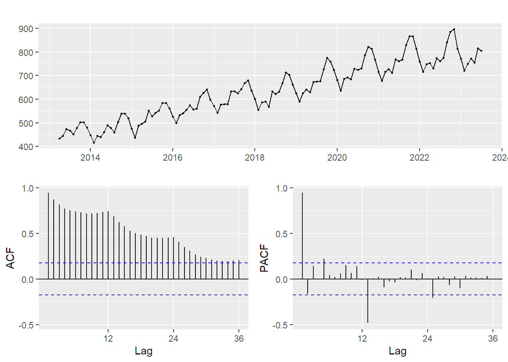

First seasonal differencing of the data gives us a stationary series. Further differencing proved to be unnecessary.

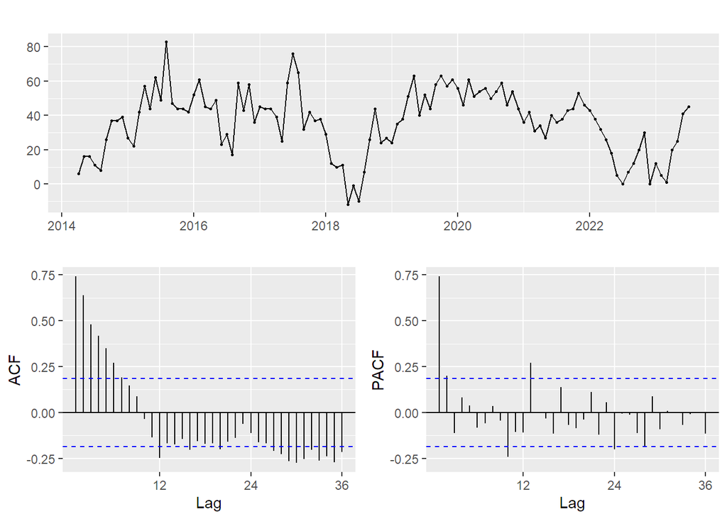

Analysis of the ACF and PACF left me with 4 potential models of the data.

- ARIMA(1,0,0)(1,1,0)

```
## Series: data.C
## ARIMA(1,0,0)(1,1,0)[12]
##
## Coefficients:
##          ar1     sar1
##       0.9713  -0.3795
## s.e.  0.0195   0.0900
##
## sigma^2 = 148.2:  log likelihood = -439.95
## AIC=885.9   AICc=886.12   BIC=894.05
```

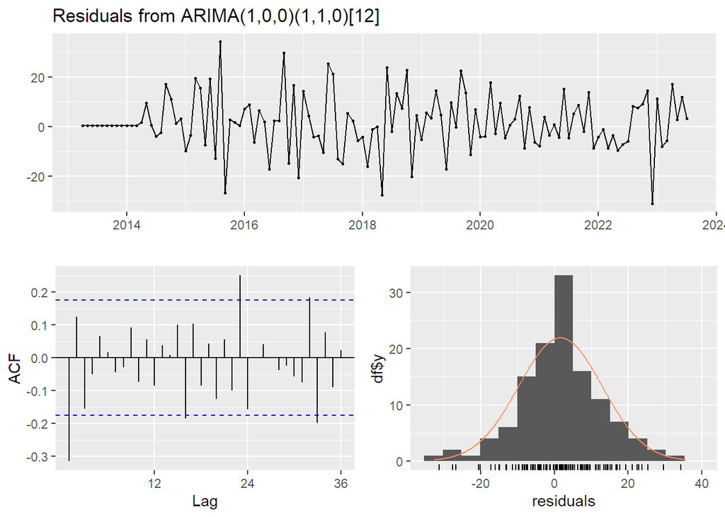

```
##
##  Ljung-Box test
##
## data:  Residuals from ARIMA(1,0,0)(1,1,0)[12]
## Q* = 49.753, df = 22, p-value = 0.0006332
##
## Model df: 2.   Total lags used: 24
```

- ARIMA(2,0,0)(1,1,0)

```
## Series: data.C
## ARIMA(2,0,0)(1,1,0)[12]
##
## Coefficients:
##          ar1     ar2     sar1
##       0.6706  0.3087  -0.4037
## s.e.  0.0893  0.0897   0.0899
##
## sigma^2 = 134.9:  log likelihood = -434.34
## AIC=876.68   AICc=877.05   BIC=887.55
```

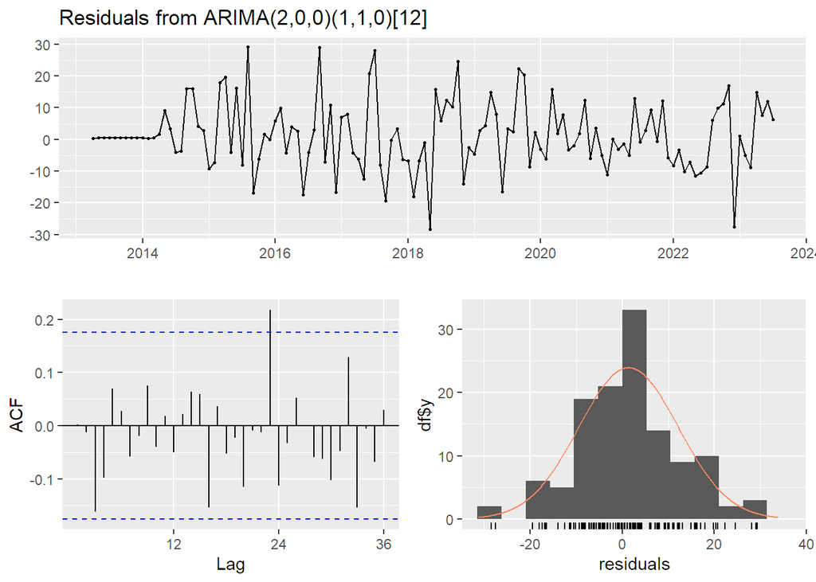

```
##
##  Ljung-Box test
##
## data:  Residuals from ARIMA(2,0,0)(1,1,0)[12]
## Q* = 23.876, df = 21, p-value = 0.2991
##
## Model df: 3.   Total lags used: 24
```

- ARIMA(1,0,0)(0,1,1)

```
## Series: data.C
## ARIMA(1,0,0)(0,1,1)[12]
##
## Coefficients:
##          ar1     sma1
##       0.9826  -0.4534
## s.e.  0.0154   0.0912
##
## sigma^2 = 143.3:  log likelihood = -438.53
## AIC=883.06   AICc=883.28   BIC=891.21
```

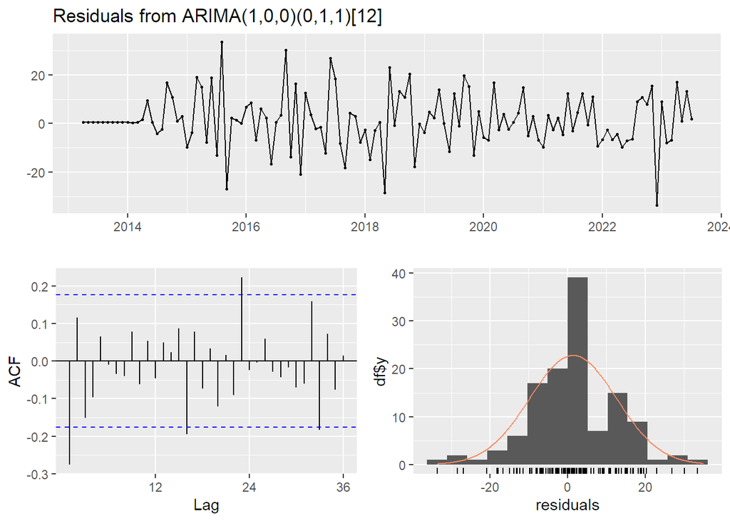

```
##
##  Ljung-Box test
##
## data:  Residuals from ARIMA(1,0,0)(0,1,1)[12]
## Q* = 38.663, df = 22, p-value = 0.01542
##
## Model df: 2.   Total lags used: 24
```

- ARIMA(2,0,0)(0,1,1)

```
## Series: data.C
## ARIMA(2,0,0)(0,1,1)[12]
##
## Coefficients:
##          ar1     ar2     sma1
##       0.7091  0.2760  -0.4149
## s.e.  0.0914  0.0911   0.0861
##
## sigma^2 = 134.3:  log likelihood = -434.15
## AIC=876.3   AICc=876.67   BIC=887.17
```

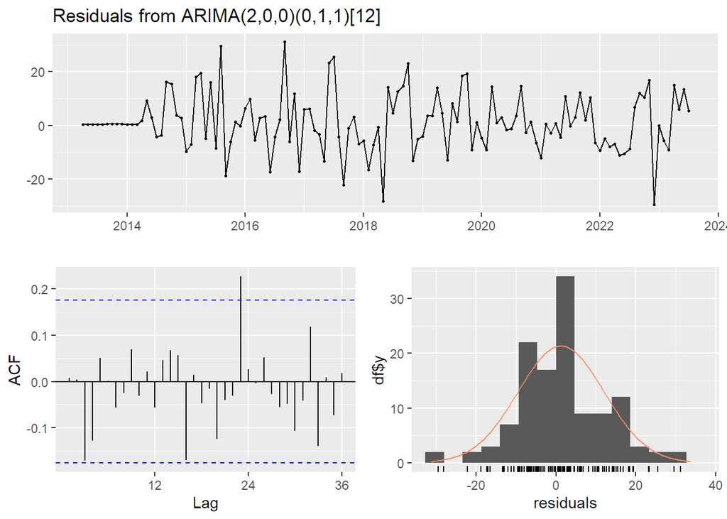

```
##
##  Ljung-Box test
##
## data:  Residuals from ARIMA(2,0,0)(0,1,1)[12]
## Q* = 24.839, df = 21, p-value = 0.2542
##
## Model df: 3.   Total lags used: 24
```

Thus, this is our prediction for the next 12 months of sales for Product C:

```
##          Point Forecast    Lo 70    Hi 70    Lo 90    Hi 90
## Aug 2023       815.3855 803.3756 827.3954 796.3254 834.4456
## Sep 2023       877.0406 862.3180 891.7632 853.6753 900.4058
## Oct 2023       918.4088 900.9665 935.8510 890.7273 946.0902
## Nov 2023       922.9328 903.3136 942.5519 891.7965 954.0690
## Dec 2023       853.5563 831.9920 875.1207 819.3330 887.7796
## Jan 2024       807.2533 783.9529 830.5537 770.2748 844.2319
## Feb 2024       759.2208 734.3393 784.1023 719.7330 798.7086
## Mar 2024       790.6301 764.2962 816.9640 748.8373 832.4228
## Apr 2024       806.1053 778.4260 833.7845 762.1774 850.0331
## May 2024       787.2260 758.2931 816.1590 741.3085 833.1436
## Jun 2024       841.4242 811.3170 871.5314 793.6431 889.2053
## Jul 2024       831.3736 800.1620 862.5852 781.8398 880.9074
```

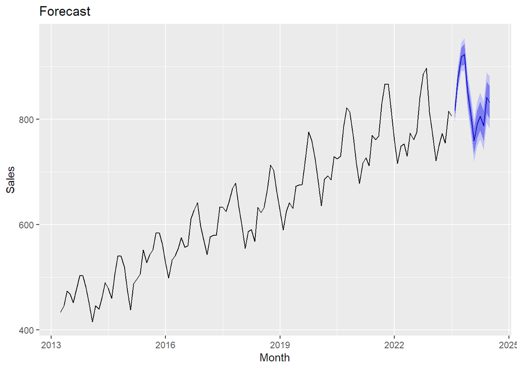